# Optimal frequentist calibration for single-arm two-stage Bayes factor designs with binary endpoints

Riko Kelter Institute of Medical Statistics and Computational Biology Faculty of Medicine, University of Cologne Cologne, Germany

28 October 2026

## 1 Introduction

This vignette illustrates how to construct *frequentist* optimal two-stage single-arm designs using the Bayes factor $BF_{01}$ as the test statistic.

We consider a proof-of-concept phase II trial with binary endpoint and hypotheses

$$H_0 : p \leq p_0, \text{ versus } H_1 : p > p_0,$$

where $p_0$ is a benchmark response probability, compare (**kelter_third_2025?**).

The decision rule is based on the Bayes factor $BF_{01}$ for $H_0$ versus $H_1$:

- small $BF_{01}$ indicate evidence against $H_0$ (efficacy),
- large $BF_{01}$ indicate evidence in favour of $H_0$ (futility).

At the final analysis, efficacy is concluded when $BF_{01} \leq k$. At the interim analysis, futility is concluded when $BF_{01} \geq k_f$.

In *frequentist calibration*, we require that:

- the type-I error is controlled at $p = p_0$,
- the power is controlled at a fixed point alternative $p = dp$,

even though the decision statistic is a Bayes factor.

## 2 Frequentist calibration: overview

Frequentist calibration is requested via

```r
calibration = "frequentist"
```

in `design_singlearm_bf()`. In this mode:

- frequentist power is evaluated at $p = dp$,
- frequentist type-I error is evaluated at $p = p_0$,
- the design prior under $H_0$ and $H_1$ still exists but does *not* drive the calibration targets; instead, it provides Bayesian operating characteristics that can be reported alongside the frequentist ones. These Bayesian trial operating characteristics are computed post-hoc for the optimal frequentist design, however. Thus, there is no formal Bayesian calibration carried out under this calibration mode.

The following calibration targets must be specified:

- `target_freq_power`: target frequentist power at `dp`,
- `target_freq_type1`: target frequentist type-I error at `p0`.

A typical choice is

- `target_freq_power = 0.7` or `0.8`,
- `target_freq_type1 = 0.1`, `0.05` or `0.025`, depending on the phase II context and statistical test used (directional or two-sided).

## 3 Manual evaluation of a two-stage design

We start with a concrete two-stage design chosen manually, for example $n_1 = 12, n_2 = 24$, and investigate its operating characteristics under frequentist calibration.

```r
res_manual <- design_singlearm_bf(
  n1_min = 8,
  n2_max = 30,
  k      = 1/3,
  k_f    = 3,
  p0     = 0.2,
  a0     = 1,
  b0     = 1,
  a1     = 1,
  b1     = 1,
  dp     = 0.4,
  da0    = 2.5,
  db0    = 2,
  da1    = 1,
  db1    = 1,
  type   = "direction",
  calibration       = "frequentist",
  algorithm         = "manual",
  interim           = 12,
  final             = 24,
  target_freq_power = 0.75,
  target_freq_type1 = 0.10
)
```

We inspect the results:

```r
summary(res_manual)
```

```
#> Summary: Single-arm two-stage Bayes factor design
#> ---------------------------------------------------------
#> Feasible: TRUE
#> Design prior under H0: Beta(2.5, 2) truncated to [0, p0]
#> Design prior under H1: Beta(1, 1) truncated to (p0, 1]
#>
#> Selected design: n1 = 12, n2 = 24
#>
#> Bayesian operating characteristics
#>   Power: 0.8379
#>   Type-I: 0.0260
#>   CE H0: NA
#>   EN H0: 14.97
#>   EN H1: 23.09
#>
#> Frequentist operating characteristics
#>   Power: 0.7838
#>   Type-I: 0.0828
#>   EN H0: 17.30
#>   EN H1: 23.00
```

In `algorithm = "manual"` mode, the function does **not** optimize over designs. It simply evaluates the chosen pair `(n1, n2)` and reports:

- Bayesian operating characteristics (prior-predictive),
- frequentist operating characteristics at `dp` and `p0`,
- whether the supplied design satisfies the specified frequentist targets.

If `Feasible` is `FALSE` in the summary, this only means that the chosen design does not meet the requested targets. It does not mean the design is incorrect; it simply does not match the desired calibration. However, even if `Feasible` is `TRUE` in the summary, this does not mean the proposed design is optimal in a frequentist sense. Therefore, among all designs which fulfill our specified target constraints on frequentist power and type-I-error rate, the resulting design needs to minimize the expected sample size $E_{H_0}[N]$ under the null hypothesis.

## 4 Optimal frequentist design

```r
res_freq <- design_singlearm_bf(
  n1_min = 5,
  n2_max = 100,
  k      = 1/10,
  k_f    = 3,
  p0     = 0.2,
  a0     = 1,
  b0     = 1,
  a1     = 1,
  b1     = 1,
  dp     = 0.5,
  da0    = 1,
  db0    = 1,
  da1    = 2.5,
  db1    = 2,
  type   = "direction",
  calibration       = "frequentist",
  target_freq_power = 0.8,
  target_freq_type1 = 0.05
)
```

We inspect the results:

```r
summary(res_freq)
```

```
#> Summary: Single-arm two-stage Bayes factor design
#> ---------------------------------------------------------
#> Feasible: TRUE
#> Calibration: frequentist
#> Design prior under H0: Beta(1, 1) truncated to [0, p0]
#> Design prior under H1: Beta(2.5, 2) truncated to (p0, 1]
#>
#> Selected design: n1 = 7, n2 = 17
#>
#> Bayesian operating characteristics
#>   Power: 0.7752
#>   Type-I: 0.0056
#>   CE H0: NA
#>   EN H0: 8.69
#>   EN H1: 16.09
#>
#> Frequentist operating characteristics
#>   Power: 0.8119
#>   Type-I: 0.0351
#>   EN H0: 11.23
#>   EN H1: 16.38
```

The summary provides all relevant information about the optimal design the algorithm computed. We can see that both the frequentist power and type-I-error are meeting our target constraints. The expected sample size under $H_0$ given in the summary is the smallest sample size among all two-stage designs in the sample size range we specified and thus the design is optimal in that sense.

The returned object also includes:

- the selected interim and final sample sizes (`n1`, `n2`),
- frequentist operating characteristics at `p0` and `dp`,
- Bayesian operating characteristics under the design priors,
- a feasibility indicator and message describing the outcome of the search.

For example:

```r
res_freq$design
```

```
#> n1 n2
#>  7 17
```

Also, more information is available by inspecting

```r
res_freq$operating_characteristics
```

which is not shown here to avoid cluttered output.

The search results can be visualized:

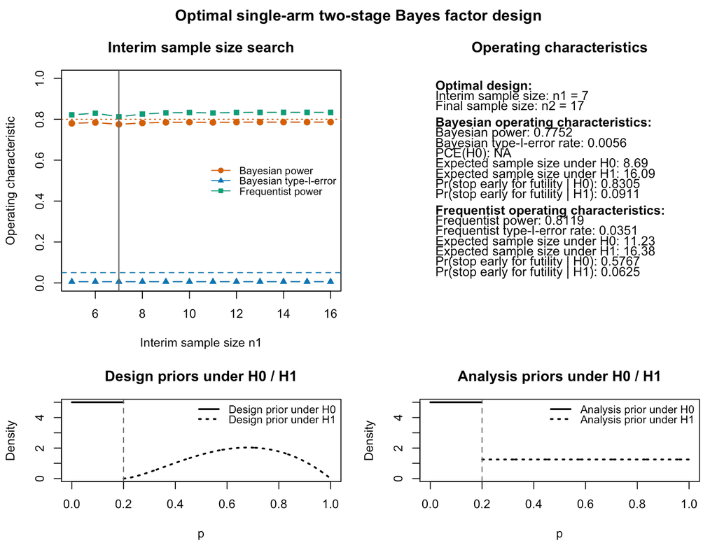

```r
plot(res_freq)
```

The plot shows how Bayesian and frequentist operating characteristics vary as a function of the interim sample size, and highlights the optimal choice selected by the algorithm.

## 5 Interpreting the frequentist design

Under `calibration = "frequentist"`, the design has the following key properties:

- The frequentist type-I error (probability of wrongly rejecting $H_0$) is controlled at or below `target_freq_type1` when the true response rate is $p = p_0$.
- The frequentist power (probability of rejecting $H_0$ when $p = dp$) is at or above `target_freq_power`.
- Among all designs within the specified bounds that satisfy these constraints, the selected design minimizes the expected sample size under $H_0$. Details are also provided in (**kelter_two_stage_2025?**).

The Bayesian operating characteristics are still reported, but they do not drive the calibration; they serve as additional information about how the design performs under the specified design priors.

## 6 Practical recommendations for frequentist calibration

When using the frequentist mode in practice:

- Choose `dp` as the clinically relevant response rate under $H_1$ where you want to guarantee power.
- Use joint priors under $H_0$ and $H_1$ that reflect realistic beliefs, even though they do not drive the calibration. The resulting Bayesian summaries can be informative.
- If no feasible design is found, consider relaxing the targets or enlarging `n2_max`. In particular, very high power with very small type-I error can be incompatible with tight sample size bounds.

## 7 References